# Daily-Level GAM Analysis of Monarch Butterfly Abundance: Results Summary

Author

Kyle Nessen

Published

September 30, 2025

## Executive Summary

This analysis examines how previous day weather conditions affect day-to-day changes in overwintering monarch butterfly abundance using Generalized Additive Mixed Models (GAMMs). The analysis was motivated by field observations suggesting that monarchs respond to wind by relocating to more sheltered positions, and by a need to examine effects over longer time horizons than the 30-minute interval analysis.

## 1. Motivation and Background

### Why a Daily-Level Analysis?

The impetus for this analysis came from discussions with Jessica Griffiths, who expressed skepticism about the absence of wind effects in the 30-minute interval analysis. Both she and I have observed monarchs at Pismo relocating in response to wind—specifically moving to the leeward side of trees when exposed to strong south winds. These observations, combined with Kingston Leong’s documented observations of wind effects, suggested the need for a different analytical approach.

**Key rationale:**

1. **Longer time horizons**: Day-to-day changes may capture more durable behavioral responses (persistence vs. emigration) than instantaneous counts
2. **Reduced temporal noise**: Using daily peak counts removes confounding effects of diurnal movement patterns (morning dispersal, afternoon cluster reformation)
3. **Different response mechanisms**: Unfavorable conditions on day *t-1* may lead to emigration detectable on day *t*

### Why Use Peak Counts?

Rather than analyzing counts at arbitrary time points, we use the 95th percentile of each day’s counts. This approach:

- Captures the maximum cluster size when butterflies are present
- Controls for measurement timing uncertainty
- Provides a robust measure less sensitive to outliers than the raw maximum
- If butterflies emigrated, the peak count would be markedly lower

### The 24-Hour Time Window

We examine previous day conditions affecting next-day abundance because:

- This represents a plausible biological response window
- Longer time horizons introduce uncertainty—we cannot track individual butterflies, only count populations
- Beyond 24 hours, we lose confidence that we’re observing the same population that experienced the initial conditions

## 2. Data Structure

```
Dataset characteristics:
```

```
- Observations: 103 day-pairs
```

```
- Deployments: 7
```

```
- Date range: 2023-11-19 to 2024-02-03
```

```
- Temporal structure: Consecutive days within deployments
```

**Response Variable:** Square-root transformed difference in 95th percentile butterfly counts between consecutive days (`butterfly_diff_95th_sqrt`)

- Selected as the most normally distributed transformation (normality score: 0.81)
- Sign-preserving transformation: maintains direction of change
- Positive values = increase in abundance; negative values = decrease

## 3. Candidate Predictor Variables

This analysis generated numerous potential environmental predictors characterizing full-day weather patterns. The table below describes all variables initially considered for model inclusion.

### 3.1 Butterfly Abundance Metrics (Previous Day)

Butterfly abundance metrics from previous day

| Variable | Description | Units | Role |
| --- | --- | --- | --- |
| max_butterflies_t_1 | Maximum count observed on previous day | count | Baseline |
| butterflies_95th_percentile_t_1 | 95th percentile of counts on previous day (baseline population measure) | count | Baseline |
| butterflies_top3_mean_t_1 | Mean of top 3 counts on previous day | count | Baseline |
| sum_butterflies_direct_sun_t_1 | Sum of all butterflies observed in direct sunlight throughout previous day (proxy for sun exposure) | cumulative count | Predictor |

### 3.2 Temperature Metrics (Previous Day)

Temperature metrics from previous day

| Variable | Description | Units |
| --- | --- | --- |
| temp_max_t_1 | Maximum temperature during daylight hours (6am-6pm) | °C |
| temp_min_t_1 | Minimum temperature during daylight hours | °C |
| temp_mean_t_1 | Mean temperature during daylight hours | °C |
| temp_at_max_count_t_1 | Temperature at the time when maximum butterfly count was observed | °C |
| hours_above_15C_t_1 | Number of hours with temperature ≥15°C (activity threshold) | hours |
| degree_hours_above_15C_t_1 | Cumulative degree-hours above 15°C (thermal energy available for activity) | degree-hours |

**Note:** Many temperature metrics are highly correlated (>0.75). Models tested various combinations to identify which best explain abundance changes.

### 3.3 Wind Metrics (Previous Day)

Wind metrics from previous day

| Variable | Description | Units |
| --- | --- | --- |
| wind_avg_sustained_t_1 | Mean sustained wind speed during daylight hours | m/s |
| wind_max_gust_t_1 | Maximum wind gust speed recorded (strongest wind event) | m/s |
| wind_gust_sum_t_1 | Sum of all gust speed measurements (cumulative wind exposure) | m/s |
| wind_gust_sum_above_2ms_t_1 | Sum of gust speeds when wind >2 m/s (threshold-weighted exposure) | m/s |
| wind_gust_hours_t_1 | Integral of gust speed over time (gust-hours of exposure) | gust-hours |
| wind_minutes_above_2ms_t_1 | Number of minutes with wind ≥2 m/s (duration above activity threshold) | minutes |
| wind_gust_sd_t_1 | Standard deviation of gust speeds (wind variability/gustiness) | m/s |
| wind_mode_gust_t_1 | Most frequent gust speed in 0.5 m/s bins (typical wind condition) | m/s |

### 3.4 Correlation Matrix: All Candidate Predictors

This correlation matrix shows all potential fixed effects initially considered. High correlations (|r| > 0.75) indicate redundancy between variables.

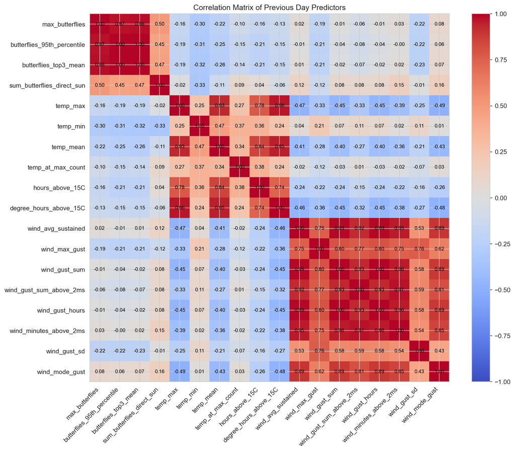

## 4. Final Model Variables

After correlation analysis, the following variables were selected for model testing to minimize multicollinearity while maintaining biological interpretability:

Variables included in final models

| Variable | Role | Description |
| --- | --- | --- |
| butterfly_diff_95th_sqrt | Response | Square-root transformed change in 95th percentile count between consecutive days |
| butterflies_95th_percentile_t_1 | Baseline (B models only) | Previous day’s 95th percentile count (baseline population size) |
| temp_max_t_1 | Predictor | Previous day’s maximum temperature (°C) |
| temp_min_t_1 | Predictor | Previous day’s minimum temperature (°C) |
| temp_at_max_count_t_1 | Predictor | Temperature when peak count occurred on previous day (°C) |
| wind_max_gust_t_1 | Predictor | Previous day’s maximum wind gust speed (m/s) |
| sum_butterflies_direct_sun_t_1 | Predictor | Sum of butterflies in direct sun on previous day |

### Correlation Matrix: Final Model Variables

This correlation matrix shows only the variables ultimately included in model testing, representing a reduced set with lower multicollinearity:

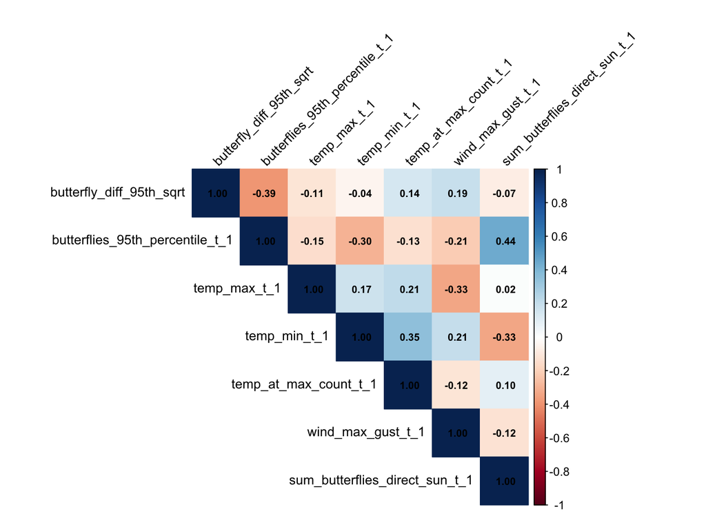

Correlation coefficients for final model variables

|  | butterfly_diff_95th_sqrt | butterflies_95th_percentile_t_1 | temp_max_t_1 | temp_min_t_1 | temp_at_max_count_t_1 | wind_max_gust_t_1 | sum_butterflies_direct_sun_t_1 |
| --- | --- | --- | --- | --- | --- | --- | --- |
| butterfly_diff_95th_sqrt | 1.000 | -0.389 | -0.112 | -0.042 | 0.145 | 0.193 | -0.072 |
| butterflies_95th_percentile_t_1 | -0.389 | 1.000 | -0.146 | -0.299 | -0.132 | -0.211 | 0.442 |
| temp_max_t_1 | -0.112 | -0.146 | 1.000 | 0.173 | 0.215 | -0.334 | 0.016 |
| temp_min_t_1 | -0.042 | -0.299 | 0.173 | 1.000 | 0.351 | 0.210 | -0.331 |
| temp_at_max_count_t_1 | 0.145 | -0.132 | 0.215 | 0.351 | 1.000 | -0.116 | 0.098 |
| wind_max_gust_t_1 | 0.193 | -0.211 | -0.334 | 0.210 | -0.116 | 1.000 | -0.122 |
| sum_butterflies_direct_sun_t_1 | -0.072 | 0.442 | 0.016 | -0.331 | 0.098 | -0.122 | 1.000 |

## 5. Modeling Approach

### 5.1 Two Model Families: Absolute vs. Proportional Effects

- Do **NOT** include previous day’s butterfly count
- Test whether environmental variables cause fixed-magnitude changes regardless of population size
- Example: “Strong wind reduces abundance by X butterflies”

**B Models (n=55): Proportional/Density-Dependent Effects**

- **Include** `butterflies_95th_percentile_t_1` as covariate or interaction term
- Test whether environmental effects scale with baseline population
- Example: “Strong wind reduces abundance by X% of the population”

### 5.2 Model Specifications

Within each family, models varied in:

1. **Fixed effects structure:**
   - Single predictors vs. combinations
   - Linear terms vs. smooth terms (splines)
   - Main effects only vs. interactions
   - Different temperature metric combinations
2. **Random effects (all models):**
   - Random intercept: `deployment_id`
   - Temporal autocorrelation: AR1 within deployments using `day_sequence | deployment_id`
3. **Correlation structures tested:**
   - No temporal correlation (baseline)
   - AR1 correlation within deployments

### 5.3 Sample Model Formulas

**Simple M models (absolute effects):**

```
M1: butterfly_diff_95th_sqrt ~ 1
M2: butterfly_diff_95th_sqrt ~ wind_max_gust_t_1
M24: butterfly_diff_95th_sqrt ~ s(wind_max_gust_t_1)
```

**Complex M models:**

```
M34: butterfly_diff_95th_sqrt ~ s(temp_at_max_count_t_1) + s(wind_max_gust_t_1) + s(sum_butterflies_direct_sun_t_1)
M41: butterfly_diff_95th_sqrt ~ temp_at_max_count_t_1 * wind_max_gust_t_1
```

**B models (proportional effects):**

```
B1: butterfly_diff_95th_sqrt ~ butterflies_95th_percentile_t_1
B19: butterfly_diff_95th_sqrt ~ butterflies_95th_percentile_t_1 + temp_at_max_count_t_1 + wind_max_gust_t_1 + sum_butterflies_direct_sun_t_1
B31: butterfly_diff_95th_sqrt ~ butterflies_95th_percentile_t_1 + s(temp_at_max_count_t_1) + s(wind_max_gust_t_1)
B51: butterfly_diff_95th_sqrt ~ butterflies_95th_percentile_t_1 * wind_max_gust_t_1
```

## 6. Model Selection Results

```
Note: Full model fitting and results are documented in the analysis document.
```

```
This summary presents key findings for interpretation.
```

[output not shown]

```
Each model tested with 2 correlation structures: no_corr and AR1
```

[output not shown]

### 6.1 Top 10 Models by AIC

The table below shows the 10 best-performing models. Note that **all top models are B models** (include baseline count), indicating that proportional/density-dependent effects provide substantially better fit than absolute effects.

**Click to expand: Top 10 Models Table**

**Model naming convention:** - First part (B19, B31, etc.): Model formula specification (see Appendix A) - Last part (AR1 or no_corr): Correlation structure used

Top 10 Models by AIC

| Model | Correlation | AIC | Delta_AIC | AIC_weight | df |
| --- | --- | --- | --- | --- | --- |
| B33_AR1 | AR1 | 668.401 | 0.000 | 0.148 | 9 |
| B29c_AR1 | AR1 | 668.671 | 0.270 | 0.129 | 8 |
| B28_AR1 | AR1 | 669.101 | 0.700 | 0.104 | 7 |
| B35_AR1 | AR1 | 669.573 | 1.172 | 0.082 | 13 |
| B37_AR1 | AR1 | 669.594 | 1.193 | 0.081 | 15 |
| B29_AR1 | AR1 | 669.685 | 1.284 | 0.078 | 6 |
| B34_AR1 | AR1 | 670.016 | 1.615 | 0.066 | 11 |
| B29a_AR1 | AR1 | 670.504 | 2.103 | 0.052 | 7 |
| B38_AR1 | AR1 | 670.691 | 2.289 | 0.047 | 10 |
| B29d_AR1 | AR1 | 670.864 | 2.463 | 0.043 | 8 |

### 6.3 Models with Strong Support (ΔAIC < 2)

Multiple models show strong empirical support, suggesting uncertainty in the precise form of environmental effects:

```
Number of models with ΔAIC < 2: 7
```

| Model | Correlation | Formula | AIC | Delta_AIC | AIC_weight | df |
| --- | --- | --- | --- | --- | --- | --- |
| B33_AR1 | AR1 | butterfly_diff_95th_sqrt ~ butterflies_95th_percentile_t_1 + s(wind_max_gust_t_1) + s(sum_butterflies_direct_sun_t_1) | 668.4011 | 0.0000 | 0.1477 | 9 |
| B29c_AR1 | AR1 | butterfly_diff_95th_sqrt ~ s(butterflies_95th_percentile_t_1) + s(wind_max_gust_t_1) | 668.6711 | 0.2700 | 0.1291 | 8 |
| B28_AR1 | AR1 | butterfly_diff_95th_sqrt ~ butterflies_95th_percentile_t_1 + s(sum_butterflies_direct_sun_t_1) | 669.1010 | 0.6999 | 0.1041 | 7 |
| B35_AR1 | AR1 | butterfly_diff_95th_sqrt ~ butterflies_95th_percentile_t_1 + s(temp_max_t_1) + s(temp_min_t_1) + s(wind_max_gust_t_1) + s(sum_butterflies_direct_sun_t_1) | 669.5730 | 1.1719 | 0.0822 | 13 |
| B37_AR1 | AR1 | butterfly_diff_95th_sqrt ~ butterflies_95th_percentile_t_1 + s(temp_max_t_1) + s(temp_min_t_1) + s(temp_at_max_count_t_1) + s(wind_max_gust_t_1) + s(sum_butterflies_direct_sun_t_1) | 669.5941 | 1.1930 | 0.0814 | 15 |
| B29_AR1 | AR1 | butterfly_diff_95th_sqrt ~ s(butterflies_95th_percentile_t_1) | 669.6853 | 1.2842 | 0.0777 | 6 |
| B34_AR1 | AR1 | butterfly_diff_95th_sqrt ~ butterflies_95th_percentile_t_1 + s(temp_at_max_count_t_1) + s(wind_max_gust_t_1) + s(sum_butterflies_direct_sun_t_1) | 670.0163 | 1.6152 | 0.0659 | 11 |

## 7. Best Model Results

### 7.1 Model Specification

**Formula:**

[output not shown]

**Model structure:** - Random effects: `~1 | deployment_id` - Correlation: AR1(form = `~day_sequence | deployment_id`) - Family: Gaussian

### 7.2 Model Performance

Best Model Performance Metrics

[output not shown]

### 7.3 Partial Response Curves

The plots below show the estimated effect of each predictor on changes in butterfly abundance, holding other variables constant. The y-axis represents the change in square-root transformed 95th percentile count.

**Interpretation guide:** - **X-axis**: Predictor variable value - **Y-axis**: Partial effect on butterfly_diff_95th_sqrt (change in abundance) - **Shaded area**: 95% confidence interval - **Horizontal line at y=0**: No change in abundance - **Above zero**: Positive effect (increase in abundance) - **Below zero**: Negative effect (decrease in abundance)

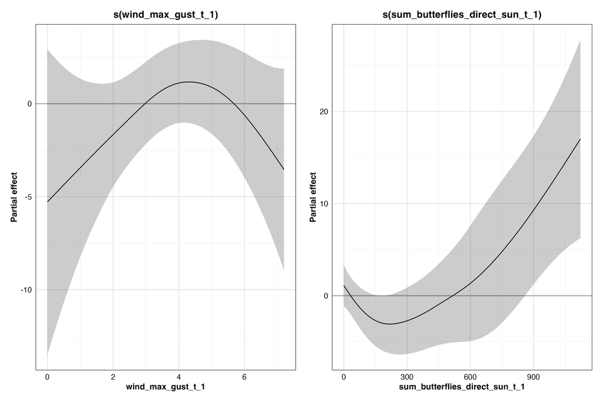

## 8. Model Diagnostics

**Notable improvement**: Daily aggregation removed many counting artifacts present in 30-minute interval analysis residuals.

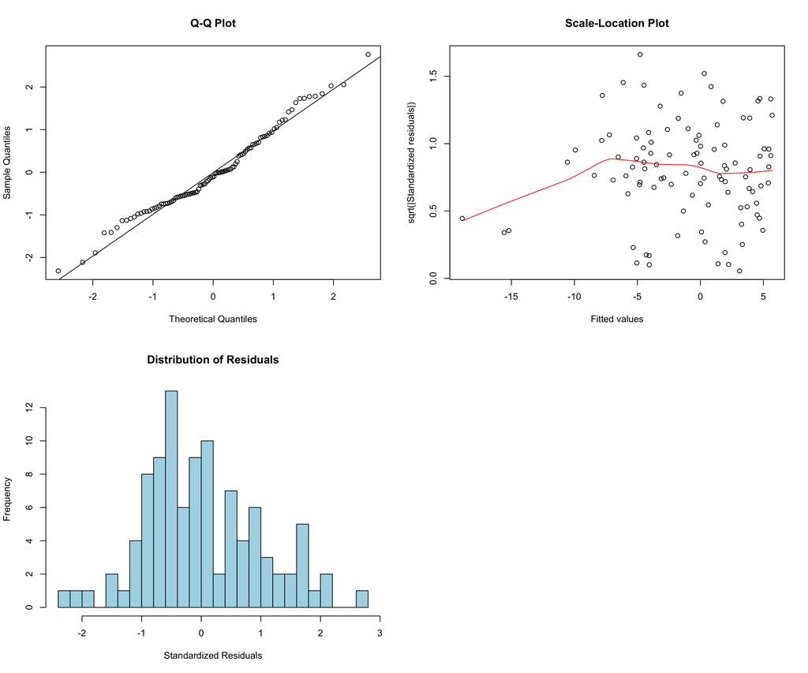

## 9. Discussion

### 9.1 Evidence for Environmental Effects

**Baseline abundance is paramount:** - All well-supported models include previous day butterfly count - Environmental effects are proportional to population size, not absolute - This suggests environmental factors modulate existing population trends rather than driving them

**Wind effects:** - Present in top models but show complex, potentially non-intuitive patterns - Effect magnitude and significance vary with model specification (p ≈ 0.08 in some versions) - Curve shape may be influenced by data artifacts (single day with zero wind) - More data might flatten or stabilize these patterns

### 9.2 Comparison with 30-Minute Interval Analysis

This daily-level analysis **does not contradict** the 30-minute interval analysis:

- **30-minute analysis**: No detectable wind effect on instantaneous counts
- **Daily analysis**: Some evidence for wind effect on day-to-day persistence, but:
  - Effect is model-dependent and marginally significant
  - Relationship is complex and not easily interpretable
  - May represent population-level behavioral decisions (emigration) vs. instantaneous movement

### 9.3 Limitations and Caveats

**Sample size:** - Only ~100 day-pairs vs. thousands of observations in 30-minute analysis - Weaker statistical power for detecting effects - Greater model uncertainty (multiple models with ΔAIC < 2)

**Time horizon constraints:** - 24-hour window chosen to balance biological plausibility with tracking uncertainty - Cannot follow individual butterflies; only observe population counts - Longer time horizons would introduce ambiguity about population identity

**Wind effect interpretation:** - Unexpected curve shape raises questions about biological plausibility - Single outlier point (zero wind day) may drive unusual pattern - Whether pattern is real or artifact requiring replication unclear

**Residual model diagnostics:** - While improved over 30-minute analysis, residuals still show some structure - AR1 correlation handles some but not all temporal dependence - Additional random effects or correlation structures might improve fit

### 9.4 Biological Interpretation

If wind effects are real (acknowledging uncertainty):

- Largest decreases at zero wind is counterintuitive
- Possible explanations:
  - Confounding with unmeasured variables (e.g., temperature inversions, microclimatic conditions)
  - Non-linear interaction between wind and temperature not captured by model
  - Artifact of limited sample size and data range

Field observations (Jessica Griffiths, personal observations) clearly show monarchs moving in response to wind. However: - These are short-term, within-site movements - May not translate to day-to-day emigration captured by peak counts - Different temporal and spatial scales between field observations and this analysis

### 9.5 Recommendations for Future Work

1. **Increase sample size**: Additional years of data would:
   - Stabilize partial effect estimates
   - Improve power to detect effects
   - Allow assessment of year-to-year consistency
2. **Investigate zero-wind day**: Detailed examination of the single day with previous wind = 0
   - Is this a data quality issue?
   - What were other conditions on that day?
   - Does excluding it change inference?
3. **Alternative time windows**: Test 48-hour, 72-hour lags to understand temporal dynamics
   - Do effects accumulate over multiple days?
   - Is 24 hours the right response window?
4. **Individual tracking**: If feasible, mark-recapture or GPS tracking would:
   - Distinguish movement from mortality/emigration
   - Directly test within-site relocation vs. leaving
   - Connect field observations to population-level patterns
5. **Microclimate measurements**: Finer-scale environmental data at cluster locations
   - Temperature and wind measurements at cluster height
   - Sun exposure and shade mapping
   - Within-tree spatial heterogeneity

## 10. Conclusions

This daily-level analysis provides a complementary perspective to the 30-minute interval analysis:

1. **Baseline population size is critical**: Day-to-day changes in abundance cannot be understood without accounting for the starting population (all top models are B models)
2. **Complex environmental relationships**: Non-linear smooth terms outperform linear effects, indicating that environmental responses are not simple or monotonic
3. **Wind effects remain ambiguous**: Some evidence for wind effects at daily timescales, but:
   - Effect size and significance are model-dependent
   - Curve shapes are difficult to interpret biologically
   - Potential data artifacts warrant caution
4. **Complementary to prior analysis**: Results do not contradict the 30-minute interval findings
   - Different temporal scales may capture different processes
   - Instantaneous movement vs. emigration decisions
5. **Sample size matters**: Limited data (~100 observations) constrains inference strength
   - Multiple competitive models indicate uncertainty
   - Additional years of data would strengthen conclusions

This analysis demonstrates that environmental effects on monarch abundance are complex and scale-dependent. While it provides some support for wind effects over daily timescales, the mechanisms remain unclear and warrant further investigation with additional data and refined methods.

## Appendix A: Complete Model Specifications

Models without previous day butterfly count, testing absolute environmental effects:

**Null and single predictor models:** - M1: `~ 1` (null model) - M2: `~ wind_max_gust_t_1` - M3: `~ temp_max_t_1` - M4: `~ temp_min_t_1` - M5: `~ temp_at_max_count_t_1` - M6: `~ sum_butterflies_direct_sun_t_1`

**Temperature combinations (linear):** - M8: `~ temp_max_t_1 + temp_min_t_1` - M9: `~ temp_max_t_1 + temp_at_max_count_t_1` - M10: `~ temp_min_t_1 + temp_at_max_count_t_1` - M11: `~ temp_max_t_1 + temp_min_t_1 + temp_at_max_count_t_1`

**Two-variable combinations:** - M12: `~ wind_max_gust_t_1 + temp_max_t_1` - M13: `~ wind_max_gust_t_1 + temp_min_t_1` - M14: `~ wind_max_gust_t_1 + temp_at_max_count_t_1` - M15: `~ wind_max_gust_t_1 + sum_butterflies_direct_sun_t_1` - M16: `~ temp_at_max_count_t_1 + sum_butterflies_direct_sun_t_1`

**Full models with various temperature specs (linear):** - M17: `~ temp_max_t_1 + wind_max_gust_t_1 + sum_butterflies_direct_sun_t_1` - M18: `~ temp_min_t_1 + wind_max_gust_t_1 + sum_butterflies_direct_sun_t_1` - M19: `~ temp_at_max_count_t_1 + wind_max_gust_t_1 + sum_butterflies_direct_sun_t_1` - M20: `~ temp_max_t_1 + temp_min_t_1 + wind_max_gust_t_1 + sum_butterflies_direct_sun_t_1` - M21: `~ temp_max_t_1 + temp_min_t_1 + temp_at_max_count_t_1 + wind_max_gust_t_1 + sum_butterflies_direct_sun_t_1`

**Single smooth terms:** - M24: `~ s(wind_max_gust_t_1)` - M25: `~ s(temp_max_t_1)` - M26: `~ s(temp_min_t_1)` - M27: `~ s(temp_at_max_count_t_1)` - M28: `~ s(sum_butterflies_direct_sun_t_1)`

**Smooth term combinations:** - M30: `~ s(temp_max_t_1) + s(temp_min_t_1)` - M31: `~ s(temp_at_max_count_t_1) + s(wind_max_gust_t_1)` - M32: `~ s(temp_at_max_count_t_1) + s(sum_butterflies_direct_sun_t_1)` - M33: `~ s(wind_max_gust_t_1) + s(sum_butterflies_direct_sun_t_1)`

**Complex smooth models:** - M34: `~ s(temp_at_max_count_t_1) + s(wind_max_gust_t_1) + s(sum_butterflies_direct_sun_t_1)` - M35: `~ s(temp_max_t_1) + s(temp_min_t_1) + s(wind_max_gust_t_1) + s(sum_butterflies_direct_sun_t_1)` - M37: `~ s(temp_max_t_1) + s(temp_min_t_1) + s(temp_at_max_count_t_1) + s(wind_max_gust_t_1) + s(sum_butterflies_direct_sun_t_1)`

**Mixed linear and smooth:** - M38: `~ temp_at_max_count_t_1 + s(wind_max_gust_t_1) + s(sum_butterflies_direct_sun_t_1)` - M39: `~ s(temp_at_max_count_t_1) + wind_max_gust_t_1 + sum_butterflies_direct_sun_t_1` - M40: `~ s(temp_at_max_count_t_1) + wind_max_gust_t_1 + s(sum_butterflies_direct_sun_t_1)`

**Interactions:** - M41: `~ temp_at_max_count_t_1 * wind_max_gust_t_1` - M42: `~ temp_at_max_count_t_1 * sum_butterflies_direct_sun_t_1` - M43: `~ wind_max_gust_t_1 * sum_butterflies_direct_sun_t_1` - M44: `~ temp_at_max_count_t_1 * wind_max_gust_t_1 + sum_butterflies_direct_sun_t_1` - M45: `~ temp_at_max_count_t_1 + wind_max_gust_t_1 * sum_butterflies_direct_sun_t_1` - M46: `~ temp_at_max_count_t_1 * wind_max_gust_t_1 * sum_butterflies_direct_sun_t_1`

**Temperature range models:** - M47: `~ I(temp_max_t_1 - temp_min_t_1)` - M48: `~ I(temp_max_t_1 - temp_min_t_1) + wind_max_gust_t_1` - M49: `~ s(I(temp_max_t_1 - temp_min_t_1))` - M50: `~ s(I(temp_max_t_1 - temp_min_t_1)) + s(wind_max_gust_t_1)`

### B Models (Proportional Effects, n=55)

All models include `butterflies_95th_percentile_t_1` to test density-dependent effects:

**Baseline-only:** - B1: `~ butterflies_95th_percentile_t_1`

**Single predictor + baseline (linear):** - B2: `~ butterflies_95th_percentile_t_1 + wind_max_gust_t_1` - B3: `~ butterflies_95th_percentile_t_1 + temp_max_t_1` - B4: `~ butterflies_95th_percentile_t_1 + temp_min_t_1` - B5: `~ butterflies_95th_percentile_t_1 + temp_at_max_count_t_1` - B6: `~ butterflies_95th_percentile_t_1 + sum_butterflies_direct_sun_t_1`

**Temperature combinations + baseline:** - B8: `~ butterflies_95th_percentile_t_1 + temp_max_t_1 + temp_min_t_1` - B9: `~ butterflies_95th_percentile_t_1 + temp_max_t_1 + temp_at_max_count_t_1` - B10: `~ butterflies_95th_percentile_t_1 + temp_min_t_1 + temp_at_max_count_t_1` - B11: `~ butterflies_95th_percentile_t_1 + temp_max_t_1 + temp_min_t_1 + temp_at_max_count_t_1`

**Two-variable combinations + baseline:** - B12: `~ butterflies_95th_percentile_t_1 + wind_max_gust_t_1 + temp_max_t_1` - B13: `~ butterflies_95th_percentile_t_1 + wind_max_gust_t_1 + temp_min_t_1` - B14: `~ butterflies_95th_percentile_t_1 + wind_max_gust_t_1 + temp_at_max_count_t_1` - B15: `~ butterflies_95th_percentile_t_1 + wind_max_gust_t_1 + sum_butterflies_direct_sun_t_1` - B16: `~ butterflies_95th_percentile_t_1 + temp_at_max_count_t_1 + sum_butterflies_direct_sun_t_1`

**Full models + baseline:** - B17: `~ butterflies_95th_percentile_t_1 + temp_max_t_1 + wind_max_gust_t_1 + sum_butterflies_direct_sun_t_1` - B18: `~ butterflies_95th_percentile_t_1 + temp_min_t_1 + wind_max_gust_t_1 + sum_butterflies_direct_sun_t_1` - B19: `~ butterflies_95th_percentile_t_1 + temp_at_max_count_t_1 + wind_max_gust_t_1 + sum_butterflies_direct_sun_t_1` - B20: `~ butterflies_95th_percentile_t_1 + temp_max_t_1 + temp_min_t_1 + wind_max_gust_t_1 + sum_butterflies_direct_sun_t_1` - B21: `~ butterflies_95th_percentile_t_1 + temp_max_t_1 + temp_min_t_1 + temp_at_max_count_t_1 + wind_max_gust_t_1 + sum_butterflies_direct_sun_t_1`

**Single smooth + baseline:** - B24: `~ butterflies_95th_percentile_t_1 + s(wind_max_gust_t_1)` - B25: `~ butterflies_95th_percentile_t_1 + s(temp_max_t_1)` - B26: `~ butterflies_95th_percentile_t_1 + s(temp_min_t_1)` - B27: `~ butterflies_95th_percentile_t_1 + s(temp_at_max_count_t_1)` - B28: `~ butterflies_95th_percentile_t_1 + s(sum_butterflies_direct_sun_t_1)`

**Smooth baseline variations:** - B29: `~ s(butterflies_95th_percentile_t_1)` - B29a: `~ s(butterflies_95th_percentile_t_1) + wind_max_gust_t_1` - B29b: `~ s(butterflies_95th_percentile_t_1) + temp_at_max_count_t_1` - B29c: `~ s(butterflies_95th_percentile_t_1) + s(wind_max_gust_t_1)` - B29d: `~ s(butterflies_95th_percentile_t_1) + s(temp_at_max_count_t_1)`

**Smooth combinations + baseline:** - B30: `~ butterflies_95th_percentile_t_1 + s(temp_max_t_1) + s(temp_min_t_1)` - B31: `~ butterflies_95th_percentile_t_1 + s(temp_at_max_count_t_1) + s(wind_max_gust_t_1)` - B32: `~ butterflies_95th_percentile_t_1 + s(temp_at_max_count_t_1) + s(sum_butterflies_direct_sun_t_1)` - B33: `~ butterflies_95th_percentile_t_1 + s(wind_max_gust_t_1) + s(sum_butterflies_direct_sun_t_1)`

**Complex smooth + baseline:** - B34: `~ butterflies_95th_percentile_t_1 + s(temp_at_max_count_t_1) + s(wind_max_gust_t_1) + s(sum_butterflies_direct_sun_t_1)` - B35: `~ butterflies_95th_percentile_t_1 + s(temp_max_t_1) + s(temp_min_t_1) + s(wind_max_gust_t_1) + s(sum_butterflies_direct_sun_t_1)` - B37: `~ butterflies_95th_percentile_t_1 + s(temp_max_t_1) + s(temp_min_t_1) + s(temp_at_max_count_t_1) + s(wind_max_gust_t_1) + s(sum_butterflies_direct_sun_t_1)`

**Mixed linear and smooth + baseline:** - B38: `~ butterflies_95th_percentile_t_1 + temp_at_max_count_t_1 + s(wind_max_gust_t_1) + s(sum_butterflies_direct_sun_t_1)` - B39: `~ butterflies_95th_percentile_t_1 + s(temp_at_max_count_t_1) + wind_max_gust_t_1 + sum_butterflies_direct_sun_t_1` - B40: `~ butterflies_95th_percentile_t_1 + s(temp_at_max_count_t_1) + wind_max_gust_t_1 + s(sum_butterflies_direct_sun_t_1)`

**Interactions + baseline:** - B41: `~ butterflies_95th_percentile_t_1 + temp_at_max_count_t_1 * wind_max_gust_t_1` - B42: `~ butterflies_95th_percentile_t_1 + temp_at_max_count_t_1 * sum_butterflies_direct_sun_t_1` - B43: `~ butterflies_95th_percentile_t_1 + wind_max_gust_t_1 * sum_butterflies_direct_sun_t_1` - B44: `~ butterflies_95th_percentile_t_1 + temp_at_max_count_t_1 * wind_max_gust_t_1 + sum_butterflies_direct_sun_t_1` - B45: `~ butterflies_95th_percentile_t_1 + temp_at_max_count_t_1 + wind_max_gust_t_1 * sum_butterflies_direct_sun_t_1` - B46: `~ butterflies_95th_percentile_t_1 + temp_at_max_count_t_1 * wind_max_gust_t_1 * sum_butterflies_direct_sun_t_1`

**Temperature range + baseline:** - B47: `~ butterflies_95th_percentile_t_1 + I(temp_max_t_1 - temp_min_t_1)` - B48: `~ butterflies_95th_percentile_t_1 + I(temp_max_t_1 - temp_min_t_1) + wind_max_gust_t_1` - B49: `~ butterflies_95th_percentile_t_1 + s(I(temp_max_t_1 - temp_min_t_1))` - B50: `~ butterflies_95th_percentile_t_1 + s(I(temp_max_t_1 - temp_min_t_1)) + s(wind_max_gust_t_1)`

**Interactions with baseline (density-dependent environmental effects):** - B51: `~ butterflies_95th_percentile_t_1 * wind_max_gust_t_1` - B52: `~ butterflies_95th_percentile_t_1 * temp_at_max_count_t_1` - B53: `~ butterflies_95th_percentile_t_1 * sum_butterflies_direct_sun_t_1` - B54: `~ butterflies_95th_percentile_t_1 * wind_max_gust_t_1 + temp_at_max_count_t_1` - B55: `~ butterflies_95th_percentile_t_1 * temp_at_max_count_t_1 + wind_max_gust_t_1`

**Note:** All models include random intercept for deployment_id and were tested with both no correlation and AR1 correlation structures.

## Appendix B: Full AIC Table

|  | Model | Base_Model | Correlation | Formula | AIC | LogLik | df | Delta_AIC | AIC_weight |
| --- | --- | --- | --- | --- | --- | --- | --- | --- | --- |
| 1 | B33_AR1 | B33 | AR1 | butterfly_diff_95th_sqrt ~ butterflies_95th_percentile_t_1 + s(wind_max_gust_t_1) + s(sum_butterflies_direct_sun_t_1) | 668.4010775095599 | -325.2005387547799 | 9 | 0 | 0.1477416056803962 |
| 2 | B29c_AR1 | B29c | AR1 | butterfly_diff_95th_sqrt ~ s(butterflies_95th_percentile_t_1) + s(wind_max_gust_t_1) | 668.6710841155262 | -326.3355420577631 | 8 | 0.2700066059663868 | 0.1290837653390899 |
| 3 | B28_AR1 | B28 | AR1 | butterfly_diff_95th_sqrt ~ butterflies_95th_percentile_t_1 + s(sum_butterflies_direct_sun_t_1) | 669.101019922612 | -327.550509961306 | 7 | 0.6999424130520993 | 0.10411474766101 |
| 4 | B35_AR1 | B35 | AR1 | butterfly_diff_95th_sqrt ~ butterflies_95th_percentile_t_1 + s(temp_max_t_1) + s(temp_min_t_1) + s(wind_max_gust_t_1) + s(sum_butterflies_direct_sun_t_1) | 669.5730189811057 | -321.7865094905529 | 13 | 1.171941471545892 | 0.08222785428306464 |
| 5 | B37_AR1 | B37 | AR1 | butterfly_diff_95th_sqrt ~ butterflies_95th_percentile_t_1 + s(temp_max_t_1) + s(temp_min_t_1) + s(temp_at_max_count_t_1) + s(wind_max_gust_t_1) + s(sum_butterflies_direct_sun_t_1) | 669.594085751188 | -319.797042875594 | 15 | 1.193008241628149 | 0.08136626233892208 |
| 6 | B29_AR1 | B29 | AR1 | butterfly_diff_95th_sqrt ~ s(butterflies_95th_percentile_t_1) | 669.6853220736622 | -328.8426610368311 | 6 | 1.284244564102323 | 0.0777378725069558 |
| 7 | B34_AR1 | B34 | AR1 | butterfly_diff_95th_sqrt ~ butterflies_95th_percentile_t_1 + s(temp_at_max_count_t_1) + s(wind_max_gust_t_1) + s(sum_butterflies_direct_sun_t_1) | 670.0162536536635 | -324.0081268268318 | 11 | 1.615176144103657 | 0.0658827579898668 |
| 8 | B29a_AR1 | B29a | AR1 | butterfly_diff_95th_sqrt ~ s(butterflies_95th_percentile_t_1) + wind_max_gust_t_1 | 670.5041176089303 | -328.2520588044652 | 7 | 2.103040099370446 | 0.05162183751632432 |
| 9 | B38_AR1 | B38 | AR1 | butterfly_diff_95th_sqrt ~ butterflies_95th_percentile_t_1 + temp_at_max_count_t_1 + s(wind_max_gust_t_1) + s(sum_butterflies_direct_sun_t_1) | 670.6905115209028 | -325.3452557604514 | 10 | 2.289434011342905 | 0.0470282194166711 |
| 10 | B29d_AR1 | B29d | AR1 | butterfly_diff_95th_sqrt ~ s(butterflies_95th_percentile_t_1) + s(temp_at_max_count_t_1) | 670.8642534888331 | -327.4321267444166 | 8 | 2.463175979273274 | 0.04311525378794225 |

[output cut: 190 more lines]

**Summary statistics:**

```
Total models fitted: 200
```

```
Models with ΔAIC < 2: 7
```

```
Models with ΔAIC < 4: 13
```

```
Models with ΔAIC < 10: 32
```

```
Best M model (no baseline):
```

```
  Model: M34_AR1
```

```
  ΔAIC: 14.07
```

```
Best B model (with baseline):
```

```
  Model: B33_AR1
```

```
  ΔAIC: 0
```

**Document prepared:** 2025-09-30 **Analysis code:** `analysis/monarch_daily_gam_analysis.qmd` **Data source:** `data/monarch_daily_lag_analysis.csv` **Data preparation:** `data_prep_daily_lag.py`